# Data replaiction

Janna M

3/30/2021

Description

The authors investigated the relationship between body and horn size , larval and adult nutrition and fitness related traits in the horned beetle.

They find that there is a possible mechanism by which larval nutrition could effect adult weight gain and strength and it is through a insulin like signaling pathway.

I used the data that they provided.The data could have been more detailed to match the code but i was able to overcome that hurdle.

I will be recreating the sexual dimorphism in in pronotum length vs Elytra in horned beetles. This a a visual and descriptive statistical analysis.

I will be recreating a Inferential statistical analysis or a Path analysis for male beetle performance, and a Path analysis for female fat content.

Elytra is a measure of body size. The pronotum it is a part of the chest cavity of thorax.

When beetles are not flying their wings are covered by a pair of modified wings called the elytra for protection . When beetles fly the elytra opens up and the wings move. The area above the elytra is the pronotum.

The data files were separated. In the original code they were apart of one text file. I decided to load the separate files.

For this reason i had to assign sex and bind_rows to combine them The rest of the code allowed me to generate a file.

I do not understand how 26 rows are missing, but this is why my results differ from the authors.

Some of the data is missing , therefore i did not accomplish the task of generating graph just like theirs.

In the future attaching the original data files would be helpful. However the code is sufficient enough to attempt to replicate this analysis using my own data.

```r
#descriptive statistics and visualization
# Read in the table
FemaleBeetle <- read.table("C://Documents and Settings/JSG-BS05V2/Desktop/Class/Beetle_data_exploratory.txt/femaledata.txt")
#combine male a female data . ( These files were separate but the original code read this in as one file . i had to combine them )
MaleBeetle <- read.table("C://Documents and Settings/JSG-BS05V2/Desktop/Class/Beetle_data_exploratory.txt/maledata.txt")
FemaleBeetle$Sex <- "female"
MaleBeetle$Sex <- "male"
#manipulate dataset
library(dplyr)
```

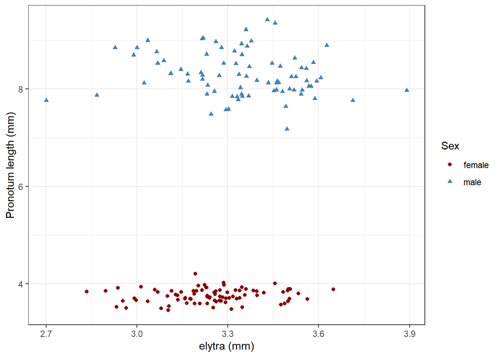

```r
# combine male and females
Beetle<- bind_rows(FemaleBeetle,MaleBeetle)
# downloading this data set was difficult and i was having trouble locating it

library(ggplot2)
library(scales)

p1 <- ggplot(data = Beetle, aes(x = Elytra, y = lnProt, shape = Sex,
colour = Sex))
p1 <- p1 + geom_point() + scale_shape_manual(values = c(16, 17)) +
scale_color_manual(values = c("darkred", "steelblue")) +
theme_bw()
p1 <- p1 + xlab("elytra (mm)") + ylab("Pronotum length (mm)")
p1
```

Inferential statistical analysis

Path analysis for male performance.

This Code was easy to replicate i just had to change the male beetle file and data name.

```r
library(lavaan)
maledata <- read.table("C://Documents and Settings/JSG-BS05V2/Desktop/Class/Beetle_data_exploratory.txt/maledata.txt")

##Specify the model
Path.full.model.perform.male<-'#Regressions
7
lnPerform~lnProt+Fat.trans+lnWtgain+Elytra+Horn+Ec.Weight.trans+Adult.diet
lnProt~Elytra+Ec.Weight.trans+lnWtgain+Horn+Adult.diet
Fat.trans~Elytra+Ec.Weight.trans+lnWtgain+Horn+Adult.diet
lnWtgain~Elytra+Ec.Weight.trans+EndBBweight+Horn+Adult.diet
Ec.Weight.trans~EndBBweight +Developmenttime
Elytra~EndBBweight +Developmenttime
Developmenttime~EndBBweight
Horn~ EndBBweight+Developmenttime
#covariances
Horn~~Elytra
Horn~~Ec.Weight.trans
lnProt~~Fat.trans
Elytra~~Ec.Weight.trans
'
## Fit the model and check the summary
Male.performance.full.model <- sem(Path.full.model.perform.male,
data = maledata, missing = "fiml")
summary(Male.performance.full.model, standardized = TRUE)
```

```
## lavaan 0.6-8 ended normally after 158 iterations
##
##   Estimator                                         ML
##   Optimization method                           NLMINB
##   Number of model parameters                        49
##
##   Number of observations                            98
##   Number of missing patterns                         8
##
## Model Test User Model:
##
##   Test statistic                                13.481
##   Degrees of freedom                                11
##   P-value (Chi-square)                           0.263
##
## Parameter Estimates:
##
##   Standard errors                             Standard
##   Information                                 Observed
##   Observed information based on                Hessian
##
## Regressions:
##                     Estimate  Std.Err  z-value  P(>|z|)   Std.lv  Std.all
##   lnPerform ~
##     lnProt            -0.006    0.068   -0.094    0.925   -0.006   -0.008
##     Fat.trans          0.102    0.245    0.418    0.676    0.102    0.054
##     lnWtgain           0.543    0.280    1.938    0.053    0.543    0.385
##     Elytra             0.281    0.264    1.063    0.288    0.281    0.168
##     Horn               0.647    0.378    1.714    0.086    0.647    0.377
##     Ec.Weight.trns    -0.163    0.088   -1.862    0.063   -0.163   -0.300
##     Adult.diet         0.009    0.069    0.130    0.897    0.009    0.012
##   lnProt ~
##     Elytra            -0.750    0.463   -1.620    0.105   -0.750   -0.353
##     Ec.Weight.trns     0.114    0.146    0.781    0.435    0.114    0.165
##     lnWtgain          -0.028    0.418   -0.067    0.946   -0.028   -0.016
##     Horn               0.157    0.670    0.234    0.815    0.157    0.072
##     Adult.diet         0.087    0.099    0.871    0.384    0.087    0.095
##   Fat.trans ~
##     Elytra             0.050    0.127    0.393    0.694    0.050    0.057
##     Ec.Weight.trns     0.031    0.040    0.776    0.438    0.031    0.108
```

[output cut: 38 more lines]

```
##    .Ec.Weight.trns    2.574    0.621    4.144    0.000    2.574    3.918
##    .Elytra            3.419    0.212   16.153    0.000    3.419   16.021
##    .Developmenttim   29.224    1.016   28.751    0.000   29.224   11.361
##    .Horn              1.412    0.206    6.850    0.000    1.412    6.785
##
## Variances:
##                    Estimate  Std.Err  z-value  P(>|z|)   Std.lv  Std.all
##    .lnPerform         0.065    0.010    6.479    0.000    0.065    0.511
##    .lnProt            0.195    0.031    6.326    0.000    0.195    0.947
##    .Fat.trans         0.015    0.002    6.432    0.000    0.015    0.429
##    .lnWtgain          0.015    0.002    6.532    0.000    0.015    0.234
##    .Ec.Weight.trns    0.257    0.037    7.000    0.000    0.257    0.596
##    .Elytra            0.028    0.004    6.800    0.000    0.028    0.625
##    .Developmenttim    6.502    0.929    7.000    0.000    6.502    0.983
##    .Horn              0.027    0.004    6.820    0.000    0.027    0.631
```

Path analysis for female fat content

I replaced the data female data. with the data female beetle . the rest of the code was simple

```r
#Specify the full model
Path.full.model.fat<-'#Regressions
lnProt~Elytra+Ec.Weight.trans+lnWtgain+ Adult.diet
Fat.trans~Elytra+Ec.Weight.trans+lnWtgain +Adult.diet
lnWtgain~Elytra+Ec.Weight.trans+EndBBweight +Adult.diet
Ec.Weight.trans~EndBBweight+Developmenttime
Elytra~EndBBweight+Developmenttime
Developmenttime~EndBBweight
#covariances
lnProt~~Fat.trans
Elytra~~Ec.Weight.trans'
# Fit the model and check the summary
female.fat.full.model <- sem(Path.full.model.fat, data = FemaleBeetle,
missing = "fiml")
summary(female.fat.full.model, standardized = TRUE)
```

```
## lavaan 0.6-8 ended normally after 118 iterations
##
##   Estimator                                         ML
##   Optimization method                           NLMINB
##   Number of model parameters                        31
##
##   Number of observations                            93
##   Number of missing patterns                         4
##
## Model Test User Model:
##
##   Test statistic                                 8.459
##   Degrees of freedom                                 8
##   P-value (Chi-square)                           0.390
##
## Parameter Estimates:
##
##   Standard errors                             Standard
##   Information                                 Observed
##   Observed information based on                Hessian
##
## Regressions:
##                     Estimate  Std.Err  z-value  P(>|z|)   Std.lv  Std.all
##   lnProt ~
##     Elytra            -0.305    0.153   -1.998    0.046   -0.305   -0.342
##     Ec.Weight.trns     0.127    0.050    2.514    0.012    0.127    0.397
##     lnWtgain           0.223    0.151    1.470    0.142    0.223    0.203
##     Adult.diet         0.062    0.029    2.128    0.033    0.062    0.216
##   Fat.trans ~
##     Elytra             0.029    0.149    0.193    0.847    0.029    0.024
##     Ec.Weight.trns     0.100    0.049    2.032    0.042    0.100    0.234
##     lnWtgain           0.661    0.147    4.500    0.000    0.661    0.448
##     Adult.diet        -0.157    0.029   -5.483    0.000   -0.157   -0.405
##   lnWtgain ~
##     Elytra             0.396    0.101    3.922    0.000    0.396    0.487
##     Ec.Weight.trns     0.079    0.037    2.125    0.034    0.079    0.272
##     EndBBweight       -0.012    0.035   -0.339    0.735   -0.012   -0.031
##     Adult.diet         0.000    0.021    0.014    0.989    0.000    0.001
##   Ec.Weight.trans ~
##     EndBBweight        0.641    0.118    5.410    0.000    0.641    0.485
```

[output cut: 16 more lines]

```
##    .lnProt            3.044    0.720    4.230    0.000    3.044   21.219
##    .Fat.trans        -3.326    0.699   -4.762    0.000   -3.326  -17.242
##    .lnWtgain          4.167    0.247   16.874    0.000    4.167   31.901
##    .Ec.Weight.trns    2.940    0.448    6.557    0.000    2.940    6.537
##    .Elytra            3.335    0.166   20.098    0.000    3.335   20.734
##    .Developmenttim   31.446    1.314   23.936    0.000   31.446   10.323
##
## Variances:
##                    Estimate  Std.Err  z-value  P(>|z|)   Std.lv  Std.all
##    .lnProt            0.017    0.003    6.519    0.000    0.017    0.831
##    .Fat.trans         0.016    0.002    6.481    0.000    0.016    0.433
##    .lnWtgain          0.009    0.001    6.519    0.000    0.009    0.513
##    .Ec.Weight.trns    0.147    0.022    6.819    0.000    0.147    0.727
##    .Elytra            0.020    0.003    6.805    0.000    0.020    0.769
##    .Developmenttim    9.042    1.326    6.819    0.000    9.042    0.974
```